# Mineral methods

Jon M. Wells

# Soil minerals, their formation, and their structures

Soils are largely made up of minerals formed by the weathering of rocks geological time and are in a constant state of flux. Different types of rocks are constantly being weathered to different extents, which creates complex and variable soils. Rocks and their weathering pathways have subsequently been linked to differences in soil behavior. Looking at different minerals and mineral fractions lets us evaluate how soils interact with many substances like water, nutrients, and organic matter.

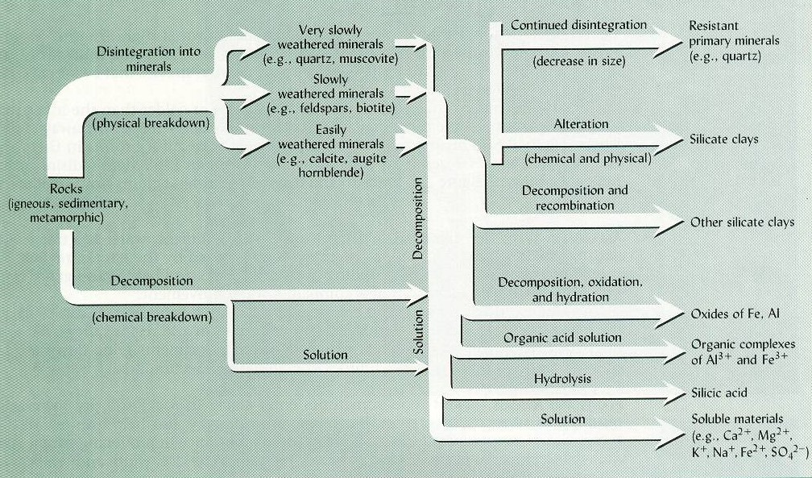

From Brady & Weil (2015) describing how rock substrate can we weathered into mineral soils

Rocks are made up of varying amounts of primary minerals and weather to secondary minerals. These minerals then have differing activities in the soil, and can change soil processes and properties.

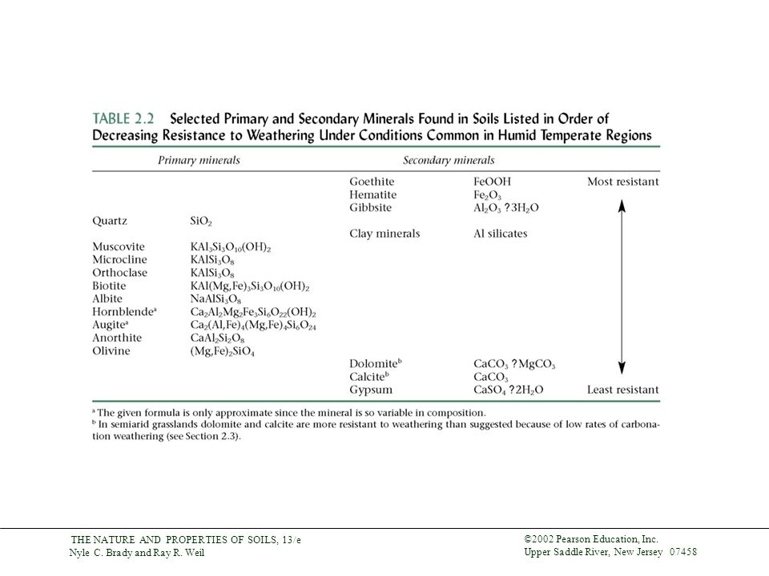

# Selective dissolutions to measure soil minerals

**List of important publications**:

Wagai et al. (2014)

Pansu et al. (2006)

# Mineral surface reactivity as a SOM storage control

**List of important publications**:

Sposito et al. (2008)